# Project_spotify-470

Here we are using 2 diff CSV files one for The Lyrics and other for details of songs like popularity,danceblity, artist name...

spotify_millsongdata.csv for Lyrics of the song,Link to the song,Song Name,Artist's name

spotify_data.csv for artist_name,track_name,popularity,genre,danceability,energy,duration,velance,..

```python
import pandas as pd
import numpy as np
import matplotlib.pyplot as plt
```

```python
data_spotifylyrics = pd.read_csv('spotify_millsongdata.csv')
data_spotifyfull = pd.read_csv('spotify_data.csv',index_col=0)
```

```python
data_spotifylyrics.info()
data_spotifyfull.info()
```

```
<class 'pandas.core.frame.DataFrame'>
RangeIndex: 57650 entries, 0 to 57649
Data columns (total 4 columns):
 #   Column  Non-Null Count  Dtype
---  ------  --------------  -----
 0   artist  57650 non-null  object
 1   song    57650 non-null  object
 2   link    57650 non-null  object
 3   text    57650 non-null  object
dtypes: object(4)
memory usage: 1.8+ MB
<class 'pandas.core.frame.DataFrame'>
Index: 1159764 entries, 0 to 1473395
Data columns (total 19 columns):
 #   Column            Non-Null Count    Dtype
---  ------            --------------    -----
 0   artist_name       1159749 non-null  object
 1   track_name        1159763 non-null  object
 2   track_id          1159764 non-null  object
 3   popularity        1159764 non-null  int64
 4   year              1159764 non-null  int64
 5   genre             1159764 non-null  object
 6   danceability      1159764 non-null  float64
 7   energy            1159764 non-null  float64
 8   key               1159764 non-null  int64
 9   loudness          1159764 non-null  float64
 10  mode              1159764 non-null  int64
 11  speechiness       1159764 non-null  float64
 12  acousticness      1159764 non-null  float64
 13  instrumentalness  1159764 non-null  float64
 14  liveness          1159764 non-null  float64
 15  valence           1159764 non-null  float64
 16  tempo             1159764 non-null  float64
 17  duration_ms       1159764 non-null  int64
 18  time_signature    1159764 non-null  int64
dtypes: float64(9), int64(6), object(4)
memory usage: 177.0+ MB
```

```python
spotifyfull_uniquevalues = data_spotifyfull.nunique()
spotifylyrics_uniquevalues = data_spotifylyrics.nunique()

print(spotifyfull_uniquevalues)
print(spotifylyrics_uniquevalues)
```

```
artist_name           64158
track_name           882360
track_id            1159764
popularity               98
year                     24
genre                    82
danceability           1364
energy                 3116
key                      12
loudness              37368
mode                      2
speechiness            1655
acousticness           5398
instrumentalness       5402
liveness               1816
valence                2177
tempo                135697
duration_ms          258021
time_signature            5
dtype: int64
artist      643
song      44824
link      57650
text      57494
dtype: int64
```

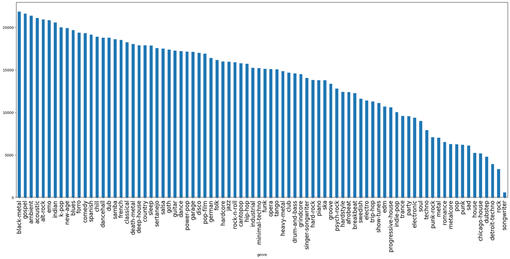

```python
plt.figure(figsize=(25, 10))
data_spotifyfull['genre'].value_counts().plot(kind='bar')
plt.xticks(fontsize=16)
plt.show()
```

```python
data_spotifylyrics[['artist','song']] = data_spotifylyrics[['artist','song']].apply(lambda x: x.str.strip().str.lower())
```

```python
data_spotifyfull[['artist_name','track_name']] = data_spotifyfull[['artist_name','track_name']].apply(lambda x: x.str.strip().str.lower())
```

```python
data_spotifylyrics.head()
```

|  | artist | song | link | text |
| --- | --- | --- | --- | --- |
| 0 | abba | ahe's my kind of girl | /a/abba/ahes+my+kind+of+girl_20598417.html | Look at her face, it's a wonderful face \r\nA... |
| 1 | abba | andante, andante | /a/abba/andante+andante_20002708.html | Take it easy with me, please \r\nTouch me gen... |
| 2 | abba | as good as new | /a/abba/as+good+as+new_20003033.html | I'll never know why I had to go \r\nWhy I had... |
| 3 | abba | bang | /a/abba/bang_20598415.html | Making somebody happy is a question of give an... |
| 4 | abba | bang-a-boomerang | /a/abba/bang+a+boomerang_20002668.html | Making somebody happy is a question of give an... |

```python
data_spotifyfull.head()
```

|  | artist_name | track_name | track_id | popularity | year | genre | danceability | energy | key | loudness | mode | speechiness | acousticness | instrumentalness | liveness | valence | tempo | duration_ms | time_signature |
| --- | --- | --- | --- | --- | --- | --- | --- | --- | --- | --- | --- | --- | --- | --- | --- | --- | --- | --- | --- |
| 0 | jason mraz | i won't give up | 53QF56cjZA9RTuuMZDrSA6 | 68 | 2012 | acoustic | 0.483 | 0.303 | 4 | -10.058 | 1 | 0.0429 | 0.6940 | 0.000000 | 0.1150 | 0.139 | 133.406 | 240166 | 3 |
| 1 | jason mraz | 93 million miles | 1s8tP3jP4GZcyHDsjvw218 | 50 | 2012 | acoustic | 0.572 | 0.454 | 3 | -10.286 | 1 | 0.0258 | 0.4770 | 0.000014 | 0.0974 | 0.515 | 140.182 | 216387 | 4 |
| 2 | joshua hyslop | do not let me go | 7BRCa8MPiyuvr2VU3O9W0F | 57 | 2012 | acoustic | 0.409 | 0.234 | 3 | -13.711 | 1 | 0.0323 | 0.3380 | 0.000050 | 0.0895 | 0.145 | 139.832 | 158960 | 4 |
| 3 | boyce avenue | fast car | 63wsZUhUZLlh1OsyrZq7sz | 58 | 2012 | acoustic | 0.392 | 0.251 | 10 | -9.845 | 1 | 0.0363 | 0.8070 | 0.000000 | 0.0797 | 0.508 | 204.961 | 304293 | 4 |
| 4 | andrew belle | sky's still blue | 6nXIYClvJAfi6ujLiKqEq8 | 54 | 2012 | acoustic | 0.430 | 0.791 | 6 | -5.419 | 0 | 0.0302 | 0.0726 | 0.019300 | 0.1100 | 0.217 | 171.864 | 244320 | 4 |

```python
track_counts = data_spotifyfull['track_id'].value_counts()
print(data_spotifyfull['genre'].unique())
print(track_counts)
data_spotifyfull['genre'].unique()
```

```
['acoustic' 'afrobeat' 'alt-rock' 'ambient' 'black-metal' 'blues'
 'breakbeat' 'cantopop' 'chicago-house' 'chill' 'classical' 'club'
 'comedy' 'country' 'dance' 'dancehall' 'death-metal' 'deep-house'
 'detroit-techno' 'disco' 'drum-and-bass' 'dub' 'dubstep' 'edm' 'electro'
 'electronic' 'emo' 'folk' 'forro' 'french' 'funk' 'garage' 'german'
 'gospel' 'goth' 'grindcore' 'groove' 'guitar' 'hard-rock' 'hardcore'
 'hardstyle' 'heavy-metal' 'hip-hop' 'house' 'indian' 'indie-pop'
 'industrial' 'jazz' 'k-pop' 'metal' 'metalcore' 'minimal-techno'
 'new-age' 'opera' 'party' 'piano' 'pop' 'pop-film' 'power-pop'
 'progressive-house' 'psych-rock' 'punk' 'punk-rock' 'rock' 'rock-n-roll'
 'romance' 'sad' 'salsa' 'samba' 'sertanejo' 'show-tunes'
 'singer-songwriter' 'ska' 'sleep' 'songwriter' 'soul' 'spanish' 'swedish'
 'tango' 'techno' 'trance' 'trip-hop']
track_id
53QF56cjZA9RTuuMZDrSA6    1
6NbeZPqKzYvgUIEqqjyhpZ    1
1jJdY9wWLqAxFa6fL7l5Yn    1
2ldpES7SIpv5FRTGmJr7dN    1
00N6HBqYLm4lllFPnXwNGC    1
                         ..
73BSfcsPqGhGkF2MLbuaIx    1
5osg2mMUwARAXXEqaX0xbu    1
02d1kSUCJKiWsS3r2QeVOQ    1
6W6xbvrkBXRXALFVDYXeMq    1
4oMiOwhDZEdBuzAfhzRHbi    1
Name: count, Length: 1159764, dtype: int64
```

```
array(['acoustic', 'afrobeat', 'alt-rock', 'ambient', 'black-metal',
       'blues', 'breakbeat', 'cantopop', 'chicago-house', 'chill',
       'classical', 'club', 'comedy', 'country', 'dance', 'dancehall',
       'death-metal', 'deep-house', 'detroit-techno', 'disco',
       'drum-and-bass', 'dub', 'dubstep', 'edm', 'electro', 'electronic',
       'emo', 'folk', 'forro', 'french', 'funk', 'garage', 'german',
       'gospel', 'goth', 'grindcore', 'groove', 'guitar', 'hard-rock',
       'hardcore', 'hardstyle', 'heavy-metal', 'hip-hop', 'house',
       'indian', 'indie-pop', 'industrial', 'jazz', 'k-pop', 'metal',
       'metalcore', 'minimal-techno', 'new-age', 'opera', 'party',
       'piano', 'pop', 'pop-film', 'power-pop', 'progressive-house',
       'psych-rock', 'punk', 'punk-rock', 'rock', 'rock-n-roll',
       'romance', 'sad', 'salsa', 'samba', 'sertanejo', 'show-tunes',
       'singer-songwriter', 'ska', 'sleep', 'songwriter', 'soul',
       'spanish', 'swedish', 'tango', 'techno', 'trance', 'trip-hop'],
      dtype=object)
```

```python
full_data = pd.merge(data_spotifyfull,data_spotifylyrics, left_on=['artist_name', 'track_name'], right_on=['artist', 'song'],how ='inner')
```

Approach 1 : we merged the data frames without renaming the columns and preserving both the columns names from 2 Df's such that "artist_name" "track_name" are manually verified with "artist" ,"song" from second DF. we can remove them if required.

```python
full_data.head()
```

|  | artist_name | track_name | track_id | popularity | year | genre | danceability | energy | key | loudness | ... | instrumentalness | liveness | valence | tempo | duration_ms | time_signature | artist | song | link | text |
| --- | --- | --- | --- | --- | --- | --- | --- | --- | --- | --- | --- | --- | --- | --- | --- | --- | --- | --- | --- | --- | --- |
| 0 | jason mraz | i won't give up | 53QF56cjZA9RTuuMZDrSA6 | 68 | 2012 | acoustic | 0.483 | 0.303 | 4 | -10.058 | ... | 0.000000 | 0.1150 | 0.139 | 133.406 | 240166 | 3 | jason mraz | i won't give up | /j/jason+mraz/i+wont+give+up_20995887.html | When I look into your eyes \r\nIt's like watc... |
| 1 | jason mraz | 93 million miles | 1s8tP3jP4GZcyHDsjvw218 | 50 | 2012 | acoustic | 0.572 | 0.454 | 3 | -10.286 | ... | 0.000014 | 0.0974 | 0.515 | 140.182 | 216387 | 4 | jason mraz | 93 million miles | /j/jason+mraz/93+million+miles_21005543.html | 93 million miles from the sun \r\nPeople get ... |
| 2 | jason mraz | living in the moment | 3ce7k1L4EkZppZPz1EJWTS | 44 | 2012 | acoustic | 0.650 | 0.628 | 7 | -7.160 | ... | 0.000000 | 0.1190 | 0.700 | 84.141 | 235080 | 4 | jason mraz | living in the moment | /j/jason+mraz/living+in+the+moment_21005539.html | If this life is one act \r\nWhy do we lay all... |
| 3 | jason mraz | the woman i love | 0AYG9AcwqEeqgAw3OvshPC | 40 | 2012 | acoustic | 0.591 | 0.647 | 4 | -8.340 | ... | 0.000066 | 0.2310 | 0.678 | 79.680 | 190752 | 4 | jason mraz | the woman i love | /j/jason+mraz/the+woman+i+love_21005540.html | Maybe I annoy you with my choices \r\nWell, y... |
| 4 | jason mraz | winter wonderland | 0zXjeGMMe7esPTvqJCN5d8 | 36 | 2012 | acoustic | 0.609 | 0.359 | 5 | -6.715 | ... | 0.000000 | 0.2210 | 0.645 | 145.178 | 127080 | 4 | jason mraz | winter wonderland | /j/jason+mraz/winter+wonderland_20755619.html | Sleigh bells ring, are you listening, \r\nIn ... |

5 rows × 23 columns

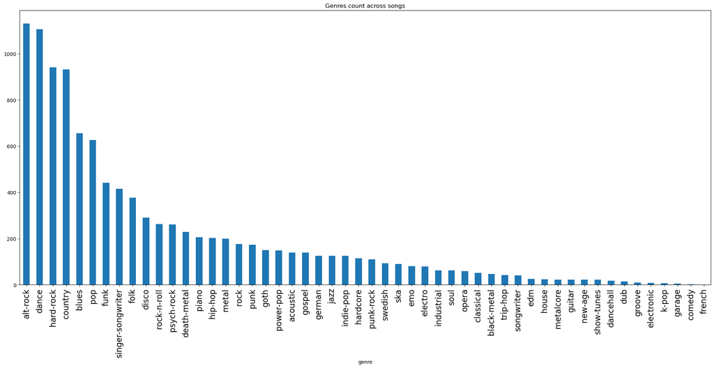

```python
plt.figure(figsize=(25, 10))
full_data['genre'].value_counts().plot(kind='bar')
plt.xticks(fontsize=16)
plt.title('Genres count across songs')
plt.show()
```

Approach 2 : we merged the data frames with renaming both the columns names from 2 Df's such that "artist_name" "track_name" with "artist" ,"song" from second DF. So here no duplicate columns, Both approaches gave the same result of 10715 instances

```python
data_spotifyfull.rename(columns={'track_name': 'song'}, inplace=True)
data_spotifyfull.rename(columns={'artist_name':'artist'},inplace=True)

data_spotifyfull = data_spotifyfull.merge(data_spotifylyrics, on=['song','artist'],how='inner')
```

```python
data_spotifyfull.head()
```

|  | artist | song | track_id | popularity | year | genre | danceability | energy | key | loudness | ... | speechiness | acousticness | instrumentalness | liveness | valence | tempo | duration_ms | time_signature | link | text |
| --- | --- | --- | --- | --- | --- | --- | --- | --- | --- | --- | --- | --- | --- | --- | --- | --- | --- | --- | --- | --- | --- |
| 0 | jason mraz | i won't give up | 53QF56cjZA9RTuuMZDrSA6 | 68 | 2012 | acoustic | 0.483 | 0.303 | 4 | -10.058 | ... | 0.0429 | 0.6940 | 0.000000 | 0.1150 | 0.139 | 133.406 | 240166 | 3 | /j/jason+mraz/i+wont+give+up_20995887.html | When I look into your eyes \r\nIt's like watc... |
| 1 | jason mraz | 93 million miles | 1s8tP3jP4GZcyHDsjvw218 | 50 | 2012 | acoustic | 0.572 | 0.454 | 3 | -10.286 | ... | 0.0258 | 0.4770 | 0.000014 | 0.0974 | 0.515 | 140.182 | 216387 | 4 | /j/jason+mraz/93+million+miles_21005543.html | 93 million miles from the sun \r\nPeople get ... |
| 2 | jason mraz | living in the moment | 3ce7k1L4EkZppZPz1EJWTS | 44 | 2012 | acoustic | 0.650 | 0.628 | 7 | -7.160 | ... | 0.0232 | 0.0483 | 0.000000 | 0.1190 | 0.700 | 84.141 | 235080 | 4 | /j/jason+mraz/living+in+the+moment_21005539.html | If this life is one act \r\nWhy do we lay all... |
| 3 | jason mraz | the woman i love | 0AYG9AcwqEeqgAw3OvshPC | 40 | 2012 | acoustic | 0.591 | 0.647 | 4 | -8.340 | ... | 0.0277 | 0.0670 | 0.000066 | 0.2310 | 0.678 | 79.680 | 190752 | 4 | /j/jason+mraz/the+woman+i+love_21005540.html | Maybe I annoy you with my choices \r\nWell, y... |
| 4 | jason mraz | winter wonderland | 0zXjeGMMe7esPTvqJCN5d8 | 36 | 2012 | acoustic | 0.609 | 0.359 | 5 | -6.715 | ... | 0.0468 | 0.7770 | 0.000000 | 0.2210 | 0.645 | 145.178 | 127080 | 4 | /j/jason+mraz/winter+wonderland_20755619.html | Sleigh bells ring, are you listening, \r\nIn ... |

5 rows × 21 columns

```python
data_spotifyfull.info()
```

```
<class 'pandas.core.frame.DataFrame'>
RangeIndex: 10715 entries, 0 to 10714
Data columns (total 21 columns):
 #   Column            Non-Null Count  Dtype
---  ------            --------------  -----
 0   artist            10715 non-null  object
 1   song              10715 non-null  object
 2   track_id          10715 non-null  object
 3   popularity        10715 non-null  int64
 4   year              10715 non-null  int64
 5   genre             10715 non-null  object
 6   danceability      10715 non-null  float64
 7   energy            10715 non-null  float64
 8   key               10715 non-null  int64
 9   loudness          10715 non-null  float64
 10  mode              10715 non-null  int64
 11  speechiness       10715 non-null  float64
 12  acousticness      10715 non-null  float64
 13  instrumentalness  10715 non-null  float64
 14  liveness          10715 non-null  float64
 15  valence           10715 non-null  float64
 16  tempo             10715 non-null  float64
 17  duration_ms       10715 non-null  int64
 18  time_signature    10715 non-null  int64
 19  link              10715 non-null  object
 20  text              10715 non-null  object
dtypes: float64(9), int64(6), object(6)
memory usage: 1.7+ MB
```

```python
print(data_spotifyfull.iloc[0])
```

```
artist                                                     jason mraz
song                                                  i won't give up
track_id                                       53QF56cjZA9RTuuMZDrSA6
popularity                                                         68
year                                                             2012
genre                                                        acoustic
danceability                                                    0.483
energy                                                          0.303
key                                                                 4
loudness                                                      -10.058
mode                                                                1
speechiness                                                    0.0429
acousticness                                                    0.694
instrumentalness                                                  0.0
liveness                                                        0.115
valence                                                         0.139
tempo                                                         133.406
duration_ms                                                    240166
time_signature                                                      3
link                       /j/jason+mraz/i+wont+give+up_20995887.html
text                When I look into your eyes  \r\nIt's like watc...
Name: 0, dtype: object
```

```python
data_spotifyfull.head()
```

|  | artist | song | track_id | popularity | year | genre | danceability | energy | key | loudness | ... | speechiness | acousticness | instrumentalness | liveness | valence | tempo | duration_ms | time_signature | link | text |
| --- | --- | --- | --- | --- | --- | --- | --- | --- | --- | --- | --- | --- | --- | --- | --- | --- | --- | --- | --- | --- | --- |
| 0 | jason mraz | i won't give up | 53QF56cjZA9RTuuMZDrSA6 | 68 | 2012 | acoustic | 0.483 | 0.303 | 4 | -10.058 | ... | 0.0429 | 0.6940 | 0.000000 | 0.1150 | 0.139 | 133.406 | 240166 | 3 | /j/jason+mraz/i+wont+give+up_20995887.html | When I look into your eyes \r\nIt's like watc... |
| 1 | jason mraz | 93 million miles | 1s8tP3jP4GZcyHDsjvw218 | 50 | 2012 | acoustic | 0.572 | 0.454 | 3 | -10.286 | ... | 0.0258 | 0.4770 | 0.000014 | 0.0974 | 0.515 | 140.182 | 216387 | 4 | /j/jason+mraz/93+million+miles_21005543.html | 93 million miles from the sun \r\nPeople get ... |
| 2 | jason mraz | living in the moment | 3ce7k1L4EkZppZPz1EJWTS | 44 | 2012 | acoustic | 0.650 | 0.628 | 7 | -7.160 | ... | 0.0232 | 0.0483 | 0.000000 | 0.1190 | 0.700 | 84.141 | 235080 | 4 | /j/jason+mraz/living+in+the+moment_21005539.html | If this life is one act \r\nWhy do we lay all... |
| 3 | jason mraz | the woman i love | 0AYG9AcwqEeqgAw3OvshPC | 40 | 2012 | acoustic | 0.591 | 0.647 | 4 | -8.340 | ... | 0.0277 | 0.0670 | 0.000066 | 0.2310 | 0.678 | 79.680 | 190752 | 4 | /j/jason+mraz/the+woman+i+love_21005540.html | Maybe I annoy you with my choices \r\nWell, y... |
| 4 | jason mraz | winter wonderland | 0zXjeGMMe7esPTvqJCN5d8 | 36 | 2012 | acoustic | 0.609 | 0.359 | 5 | -6.715 | ... | 0.0468 | 0.7770 | 0.000000 | 0.2210 | 0.645 | 145.178 | 127080 | 4 | /j/jason+mraz/winter+wonderland_20755619.html | Sleigh bells ring, are you listening, \r\nIn ... |

5 rows × 21 columns

```python
df = data_spotifyfull[['track_id','genre','song','text']]
```

Here we can only perform the song(item) based similarity based on items userscores(popularity),text,year... , here we can't perfrom user based simialrity beacuse we dont have rating's of muiple users only one score thats "popularity" as common average score.

```
2 approaches can be performed 1) ignoring the text and all other features
                              2) Taking the text similarity of song
```

We can do either clustering of songs based on the text similarity or based on other features and do recommendations

```
Here we go with 2) Taking the text similarity of song for I)recommendations and II)clustering of songs and identify by genre
```

```python
df.head()
```

|  | track_id | genre | song | text |
| --- | --- | --- | --- | --- |
| 0 | 53QF56cjZA9RTuuMZDrSA6 | acoustic | i won't give up | When I look into your eyes \r\nIt's like watc... |
| 1 | 1s8tP3jP4GZcyHDsjvw218 | acoustic | 93 million miles | 93 million miles from the sun \r\nPeople get ... |
| 2 | 3ce7k1L4EkZppZPz1EJWTS | acoustic | living in the moment | If this life is one act \r\nWhy do we lay all... |
| 3 | 0AYG9AcwqEeqgAw3OvshPC | acoustic | the woman i love | Maybe I annoy you with my choices \r\nWell, y... |
| 4 | 0zXjeGMMe7esPTvqJCN5d8 | acoustic | winter wonderland | Sleigh bells ring, are you listening, \r\nIn ... |

```python
df.count()
```

```
track_id    10715
genre       10715
song        10715
text        10715
dtype: int64
```

Here song is docid and text is the group of terms which needs to be pre-processed into tokens

```python
# import pandas as pd
# from sklearn.feature_extraction.text import CountVectorizer



# # Initialize the CountVectorizer
# vectorizer = CountVectorizer()

# # Fit and transform the text data
# X = vectorizer.fit_transform(df['text'])

# # Convert the DTM to a DataFrame for better readability
# #dtm_df = pd.DataFrame(X.toarray(), columns=vectorizer.get_feature_names_out(), index=df['song'])
# dtm_df = pd.DataFrame(X.toarray(), columns=vectorizer.get_feature_names_out())

# # Display the Document-Term Matrix
# print(dtm_df)

# # Save the Document-Term Matrix to a CSV file
# #dtm_df.to_csv('document_term_matrix.csv', index=True)
```

```python
# This text has some unwanted text like 0000,01,12,007...numeric stringvalues and 1x,12pm.combination strings , lets remove them
import re


def custom_cleaning(text):
    # Remove purely numeric words
    text = re.sub(r'\b\d+\b', '', text)

    # Remove time-related patterns (e.g., 12am, 3pm)
    text = re.sub(r'\b\d{1,2}[ap]m\b', '', text)

    # Remove other words containing numbers
    text = re.sub(r'\b\w*\d\w*\b', '', text)

    return text


# Apply the function to the text data
#df['text'] = df['text'].apply(remove_numeric_strings)
# Apply the function to the text data using .loc to avoid SettingWithCopyWarning
df.loc[:, 'text'] = df['text'].apply(custom_cleaning)
```

```python
import pandas as pd
from sklearn.feature_extraction.text import CountVectorizer

# Sample data (replace this with your actual data)

#df = pd.DataFrame(data)

# Initialize the CountVectorizer
vectorizer = CountVectorizer()

# Fit and transform the text data
X = vectorizer.fit_transform(df['text'])

# Extract the terms (feature names)
terms = vectorizer.get_feature_names_out()

# Convert the terms to a DataFrame
terms_df = pd.DataFrame(terms, columns=['Term'])

# Save the terms to a separate CSV file
terms_df.to_csv('terms.csv', index=False)

# Convert the DTM to a DataFrame without column names
dtm_df = pd.DataFrame(X.toarray())

# Display the Document-Term Matrix
print(dtm_df)

# Save the Document-Term Matrix to a CSV file without column names
#dtm_df.to_csv('document_term_matrix_no_column_names.csv', index=False, header=False)
```

```
       0      1      2      3      4      5      6      7      8      9      \
0          0      0      0      0      0      0      0      0      0      0
1          0      0      0      0      0      0      0      0      0      0
2          0      0      0      0      0      0      0      0      0      0
3          0      0      0      0      0      0      0      0      0      0
4          0      0      0      0      0      0      0      0      0      0
...      ...    ...    ...    ...    ...    ...    ...    ...    ...    ...
10710      0      0      0      0      0      0      0      0      0      0
10711      0      0      0      0      0      0      0      0      0      0
10712      0      0      0      0      0      0      0      0      0      0
10713      0      0      0      0      0      0      0      0      0      0
10714      0      0      0      0      0      0      0      0      0      0

       ...  32096  32097  32098  32099  32100  32101  32102  32103  32104  \
0      ...      0      0      0      0      0      0      0      0      0
```

[output cut: 25 more lines]

```python
terms_df.tail(10)
```

|  | Term |
| --- | --- |
| 32096 | zoroastrian |
| 32097 | zorro |
| 32098 | zs |
| 32099 | zuhm |
| 32100 | zulu |
| 32101 | zumba |
| 32102 | zuzu |
| 32103 | zy |
| 32104 | zz |
| 32105 | zzay |

```python
terms_df.head(30)
```

|  | Term |
| --- | --- |
| 0 | aa |
| 1 | aaa |
| 2 | aaaa |
| 3 | aaaaaaaaaaaaah |
| 4 | aaaah |
| 5 | aaaahh |
| 6 | aaah |
| 7 | aaahh |
| 8 | aaahhhh |
| 9 | aaahhhhhhh |
| 10 | aaar |
| 11 | aah |
| 12 | aahh |
| 13 | aaliyah |
| 14 | aand |
| 15 | aaoh |
| 16 | aaoooooo |
| 17 | aaow |
| 18 | aaron |
| 19 | aawaah |
| 20 | aay |
| 21 | aayy |
| 22 | ab |
| 23 | abacinate |
| 24 | abandon |
| 25 | abandoned |
| 26 | abandonedly |
| 27 | abandoning |
| 28 | abandonment |
| 29 | abandons |

```python
import numpy as np
import pandas as pd
from sklearn.feature_extraction.text import TfidfTransformer
from sklearn.model_selection import train_test_split
from sklearn.cluster import KMeans
from sklearn.metrics.pairwise import cosine_similarity, pairwise_distances
from sklearn.metrics import homogeneity_score, completeness_score


# TFIDF on Document-Term Matrix to get TF-IDF scores
tfidf_transformer = TfidfTransformer()
tfidf_matrix = tfidf_transformer.fit_transform(dtm_df)

# Conversion into  TF-IDF matrix to DF
tfidf_df = pd.DataFrame(tfidf_matrix.toarray())

# 'genre_labels'
genre_labels = df['genre'].tolist()

# Split the data into training and testing sets (80% train, 20% test)
train_data, test_data, train_labels, test_labels = train_test_split(tfidf_df, genre_labels, test_size=0.2, random_state=42)


unique_categories = len(set(genre_labels))

# Perform KMeans clustering
kmeans = KMeans(n_clusters=unique_categories, random_state=42)
kmeans.fit(train_data)


cosine_similarities = cosine_similarity(test_data, kmeans.cluster_centers_)


predicted_clusters = np.argmax(cosine_similarities, axis=1)

homogeneity = homogeneity_score(test_labels, predicted_clusters)
completeness = completeness_score(test_labels, predicted_clusters)

print(f"Homogeneity Score: {homogeneity:.4f}")
print(f"Completeness Score: {completeness:.4f}")


category_labels = {i: label for i, label in enumerate(set(genre_labels))}

# Print predicted clusters and cosine similarities for each test document
for i, (predicted_cluster, cosine_sim) in enumerate(zip(predicted_clusters, np.max(cosine_similarities, axis=1))):
    print(f"Test Document {i+1}: Predicted Category: {category_labels[predicted_cluster]}, Cosine Similarity: {cosine_sim:.4f}")
```

```
Homogeneity Score: 0.1572
Completeness Score: 0.1487
Test Document 1: Predicted Category: hip-hop, Cosine Similarity: 0.3426
Test Document 2: Predicted Category: disco, Cosine Similarity: 0.3657
Test Document 3: Predicted Category: dancehall, Cosine Similarity: 0.3464
Test Document 4: Predicted Category: hardcore, Cosine Similarity: 0.3993
Test Document 5: Predicted Category: house, Cosine Similarity: 0.3412
Test Document 6: Predicted Category: groove, Cosine Similarity: 0.4609
Test Document 7: Predicted Category: rock, Cosine Similarity: 0.2045
Test Document 8: Predicted Category: emo, Cosine Similarity: 0.1572
Test Document 9: Predicted Category: emo, Cosine Similarity: 0.2433
Test Document 10: Predicted Category: country, Cosine Similarity: 0.3020
Test Document 11: Predicted Category: dub, Cosine Similarity: 0.3122
Test Document 12: Predicted Category: classical, Cosine Similarity: 0.3813
Test Document 13: Predicted Category: hard-rock, Cosine Similarity: 0.4923
Test Document 14: Predicted Category: hard-rock, Cosine Similarity: 0.3396
Test Document 15: Predicted Category: dub, Cosine Similarity: 0.4582
Test Document 16: Predicted Category: country, Cosine Similarity: 0.2553
Test Document 17: Predicted Category: death-metal, Cosine Similarity: 0.3392
Test Document 18: Predicted Category: disco, Cosine Similarity: 0.3537
Test Document 19: Predicted Category: groove, Cosine Similarity: 0.4322
Test Document 20: Predicted Category: country, Cosine Similarity: 0.2708
Test Document 21: Predicted Category: french, Cosine Similarity: 0.3268
Test Document 22: Predicted Category: hip-hop, Cosine Similarity: 0.3309
Test Document 23: Predicted Category: indie-pop, Cosine Similarity: 0.3353
Test Document 24: Predicted Category: dub, Cosine Similarity: 0.3584
Test Document 25: Predicted Category: alt-rock, Cosine Similarity: 0.5799
Test Document 26: Predicted Category: dub, Cosine Similarity: 0.2167
Test Document 27: Predicted Category: rock, Cosine Similarity: 0.4448
Test Document 28: Predicted Category: guitar, Cosine Similarity: 0.3503
Test Document 29: Predicted Category: gospel, Cosine Similarity: 0.4606
Test Document 30: Predicted Category: folk, Cosine Similarity: 0.2780
Test Document 31: Predicted Category: country, Cosine Similarity: 0.3509
Test Document 32: Predicted Category: disco, Cosine Similarity: 0.5358
Test Document 33: Predicted Category: disco, Cosine Similarity: 0.5002
Test Document 34: Predicted Category: hardcore, Cosine Similarity: 0.3972
Test Document 35: Predicted Category: house, Cosine Similarity: 0.2646
Test Document 36: Predicted Category: dub, Cosine Similarity: 0.4670
Test Document 37: Predicted Category: dub, Cosine Similarity: 0.3896
Test Document 38: Predicted Category: dub, Cosine Similarity: 0.3748
```

[output cut: 2090 more lines]

```
Test Document 2129: Predicted Category: guitar, Cosine Similarity: 0.3628
Test Document 2130: Predicted Category: metalcore, Cosine Similarity: 0.4910
Test Document 2131: Predicted Category: dance, Cosine Similarity: 0.4592
Test Document 2132: Predicted Category: electro, Cosine Similarity: 0.1945
Test Document 2133: Predicted Category: groove, Cosine Similarity: 0.2041
Test Document 2134: Predicted Category: hardcore, Cosine Similarity: 0.2786
Test Document 2135: Predicted Category: jazz, Cosine Similarity: 0.1359
Test Document 2136: Predicted Category: disco, Cosine Similarity: 0.4307
Test Document 2137: Predicted Category: comedy, Cosine Similarity: 0.3473
Test Document 2138: Predicted Category: metal, Cosine Similarity: 0.4974
Test Document 2139: Predicted Category: pop, Cosine Similarity: 0.3832
Test Document 2140: Predicted Category: country, Cosine Similarity: 0.2844
Test Document 2141: Predicted Category: guitar, Cosine Similarity: 0.3561
Test Document 2142: Predicted Category: comedy, Cosine Similarity: 0.3157
Test Document 2143: Predicted Category: comedy, Cosine Similarity: 0.3733
```

```python
test_data[:1]
```

|  | 0 | 1 | 2 | 3 | 4 | 5 | 6 | 7 | 8 | 9 | ... | 32096 | 32097 | 32098 | 32099 | 32100 | 32101 | 32102 | 32103 | 32104 | 32105 |
| --- | --- | --- | --- | --- | --- | --- | --- | --- | --- | --- | --- | --- | --- | --- | --- | --- | --- | --- | --- | --- | --- |
| 10308 | 0.0 | 0.0 | 0.0 | 0.0 | 0.0 | 0.0 | 0.0 | 0.0 | 0.0 | 0.0 | ... | 0.0 | 0.0 | 0.0 | 0.0 | 0.0 | 0.0 | 0.0 | 0.0 | 0.0 | 0.0 |

1 rows × 32106 columns

Seems the data is good now, we shall split the data into train and test data and perfrom TFIDF

```python
test_labels[:1]
```

```
['classical']
```

```python
from sklearn.discriminant_analysis import LinearDiscriminantAnalysis as LDA
import numpy as np
import pandas as pd
from sklearn.feature_extraction.text import TfidfTransformer
from sklearn.model_selection import train_test_split
from sklearn.cluster import KMeans
from sklearn.metrics.pairwise import cosine_similarity
from sklearn.metrics import homogeneity_score, completeness_score, silhouette_score


tfidf_transformer = TfidfTransformer()
tfidf_matrix = tfidf_transformer.fit_transform(dtm_df)
tfidf_df = pd.DataFrame(tfidf_matrix.toarray())
genre_labels = df['genre'].tolist()


train_data, test_data, train_labels, test_labels = train_test_split(tfidf_df, genre_labels, test_size=0.2, random_state=42)

# LDA to reduce dimensionality
lda = LDA(n_components=min(len(set(train_labels)) - 1, train_data.shape[1]))
train_data_lda = lda.fit_transform(train_data, train_labels)
test_data_lda = lda.transform(test_data)


unique_categories = len(set(genre_labels))

# KMeans clustering on the LDA-reduced
kmeans = KMeans(n_clusters=unique_categories, random_state=42)
kmeans.fit(train_data_lda)

#  cosine similarity between each test document and cluster centroids
cosine_similarities = cosine_similarity(test_data_lda, kmeans.cluster_centers_)

# cosine similarity for each test document
predicted_clusters = np.argmax(cosine_similarities, axis=1)


category_labels = {i: label for i, label in enumerate(set(genre_labels))}
for i, (predicted_cluster, cosine_sim) in enumerate(zip(predicted_clusters, np.max(cosine_similarities, axis=1))):
    print(f"Test Document {i+1}: Predicted Category: {category_labels[predicted_cluster]}, Cosine Similarity: {cosine_sim:.4f}")

# Compute homogeneity and completeness scores
homogeneity_lda = homogeneity_score(test_labels, predicted_clusters)
completeness_lda = completeness_score(test_labels, predicted_clusters)
silhouette_avg = silhouette_score(test_data_lda, predicted_clusters)

print(f"LDA - Homogeneity Score: {homogeneity_lda}")
print(f"LDA - Completeness Score: {completeness_lda}")
print(f"LDA - Silhouette Score: {silhouette_avg}")
```

```
Test Document 1: Predicted Category: swedish, Cosine Similarity: 0.5280
Test Document 2: Predicted Category: hip-hop, Cosine Similarity: 0.8706
Test Document 3: Predicted Category: french, Cosine Similarity: 1.0000
Test Document 4: Predicted Category: disco, Cosine Similarity: 0.8468
Test Document 5: Predicted Category: opera, Cosine Similarity: 0.8678
Test Document 6: Predicted Category: punk, Cosine Similarity: 0.5633
Test Document 7: Predicted Category: disco, Cosine Similarity: 0.5682
Test Document 8: Predicted Category: house, Cosine Similarity: 0.5863
Test Document 9: Predicted Category: punk, Cosine Similarity: 0.6851
Test Document 10: Predicted Category: french, Cosine Similarity: 0.5916
Test Document 11: Predicted Category: emo, Cosine Similarity: 0.6353
Test Document 12: Predicted Category: emo, Cosine Similarity: 0.7471
Test Document 13: Predicted Category: alt-rock, Cosine Similarity: 0.6411
Test Document 14: Predicted Category: rock-n-roll, Cosine Similarity: 0.6629
Test Document 15: Predicted Category: country, Cosine Similarity: 0.6986
Test Document 16: Predicted Category: rock-n-roll, Cosine Similarity: 0.5921
Test Document 17: Predicted Category: disco, Cosine Similarity: 0.7872
Test Document 18: Predicted Category: disco, Cosine Similarity: 0.7483
Test Document 19: Predicted Category: swedish, Cosine Similarity: 0.5964
Test Document 20: Predicted Category: punk, Cosine Similarity: 0.5263
Test Document 21: Predicted Category: black-metal, Cosine Similarity: 0.4168
Test Document 22: Predicted Category: singer-songwriter, Cosine Similarity: 0.7100
Test Document 23: Predicted Category: singer-songwriter, Cosine Similarity: 0.6770
Test Document 24: Predicted Category: house, Cosine Similarity: 0.4952
Test Document 25: Predicted Category: punk, Cosine Similarity: 0.5959
Test Document 26: Predicted Category: hardcore, Cosine Similarity: 0.5493
Test Document 27: Predicted Category: punk, Cosine Similarity: 0.6182
Test Document 28: Predicted Category: opera, Cosine Similarity: 0.5754
Test Document 29: Predicted Category: disco, Cosine Similarity: 0.6832
Test Document 30: Predicted Category: singer-songwriter, Cosine Similarity: 0.7098
Test Document 31: Predicted Category: hardcore, Cosine Similarity: 0.6570
Test Document 32: Predicted Category: metal, Cosine Similarity: 0.6743
Test Document 33: Predicted Category: opera, Cosine Similarity: 0.6655
Test Document 34: Predicted Category: industrial, Cosine Similarity: 0.6111
Test Document 35: Predicted Category: house, Cosine Similarity: 0.6825
Test Document 36: Predicted Category: electro, Cosine Similarity: 0.6025
Test Document 37: Predicted Category: electro, Cosine Similarity: 0.5227
Test Document 38: Predicted Category: k-pop, Cosine Similarity: 0.6796
Test Document 39: Predicted Category: emo, Cosine Similarity: 0.7080
Test Document 40: Predicted Category: electro, Cosine Similarity: 0.7399
```

[output cut: 2091 more lines]

```
Test Document 2132: Predicted Category: classical, Cosine Similarity: 0.5771
Test Document 2133: Predicted Category: blues, Cosine Similarity: 0.5629
Test Document 2134: Predicted Category: funk, Cosine Similarity: 0.4271
Test Document 2135: Predicted Category: blues, Cosine Similarity: 0.7371
Test Document 2136: Predicted Category: hardcore, Cosine Similarity: 0.6604
Test Document 2137: Predicted Category: metal, Cosine Similarity: 0.8535
Test Document 2138: Predicted Category: disco, Cosine Similarity: 0.6107
Test Document 2139: Predicted Category: hip-hop, Cosine Similarity: 0.5388
Test Document 2140: Predicted Category: jazz, Cosine Similarity: 0.4342
Test Document 2141: Predicted Category: electro, Cosine Similarity: 0.7288
Test Document 2142: Predicted Category: country, Cosine Similarity: 0.5698
Test Document 2143: Predicted Category: swedish, Cosine Similarity: 0.5781
LDA - Homogeneity Score: 0.12527471733792175
LDA - Completeness Score: 0.12317359639514172
LDA - Silhouette Score: -0.16699975219700416
```

```python
from sklearn.decomposition import PCA
import numpy as np
import pandas as pd
from sklearn.feature_extraction.text import TfidfTransformer
from sklearn.model_selection import train_test_split
from sklearn.cluster import KMeans
from sklearn.metrics.pairwise import cosine_similarity
from sklearn.metrics import homogeneity_score, completeness_score


tfidf_transformer = TfidfTransformer()


tfidf_matrix = tfidf_transformer.fit_transform(dtm_df)


tfidf_df = pd.DataFrame(tfidf_matrix.toarray())


genre_labels = df['genre'].tolist()


train_data, test_data, train_labels, test_labels = train_test_split(tfidf_df, genre_labels, test_size=0.2, random_state=42)

# Apply PCA to reduce dimensionality
pca = PCA(n_components=0.95)  # Retain 95% of the variance
train_data_pca = pca.fit_transform(train_data)
test_data_pca = pca.transform(test_data)


unique_categories = len(set(genre_labels))

#  KMeans clustering on the PCA-reduced data
kmeans = KMeans(n_clusters=unique_categories, random_state=42)
kmeans.fit(train_data_pca)


cosine_similarities = cosine_similarity(test_data_pca, kmeans.cluster_centers_)


predicted_clusters = np.argmax(cosine_similarities, axis=1)


category_labels = {i: label for i, label in enumerate(set(genre_labels))}


for i, (predicted_cluster, cosine_sim) in enumerate(zip(predicted_clusters, np.max(cosine_similarities, axis=1))):
    print(f"Test Document {i+1}: Predicted Category: {category_labels[predicted_cluster]}, Cosine Similarity: {cosine_sim:.4f}")


homogeneity_pca = homogeneity_score(test_labels, predicted_clusters)
completeness_pca = completeness_score(test_labels, predicted_clusters)

print(f"PCA - Homogeneity Score: {homogeneity_pca}")
print(f"PCA - Completeness Score: {completeness_pca}")
```

```
Test Document 1: Predicted Category: swedish, Cosine Similarity: 0.2346
Test Document 2: Predicted Category: new-age, Cosine Similarity: 0.3205
Test Document 3: Predicted Category: guitar, Cosine Similarity: 0.2968
Test Document 4: Predicted Category: acoustic, Cosine Similarity: 0.2317
Test Document 5: Predicted Category: garage, Cosine Similarity: 0.2094
Test Document 6: Predicted Category: classical, Cosine Similarity: 0.2241
Test Document 7: Predicted Category: hardcore, Cosine Similarity: 0.1686
Test Document 8: Predicted Category: hardcore, Cosine Similarity: 0.1819
Test Document 9: Predicted Category: hardcore, Cosine Similarity: 0.0961
Test Document 10: Predicted Category: acoustic, Cosine Similarity: 0.2162
Test Document 11: Predicted Category: blues, Cosine Similarity: 0.1303
Test Document 12: Predicted Category: blues, Cosine Similarity: 0.1298
Test Document 13: Predicted Category: punk-rock, Cosine Similarity: 0.4758
Test Document 14: Predicted Category: punk-rock, Cosine Similarity: 0.2825
Test Document 15: Predicted Category: hard-rock, Cosine Similarity: 0.2080
Test Document 16: Predicted Category: punk, Cosine Similarity: 0.1721
Test Document 17: Predicted Category: acoustic, Cosine Similarity: 0.1703
Test Document 18: Predicted Category: jazz, Cosine Similarity: 0.4363
Test Document 19: Predicted Category: dancehall, Cosine Similarity: 0.1844
Test Document 20: Predicted Category: psych-rock, Cosine Similarity: 0.2476
Test Document 21: Predicted Category: house, Cosine Similarity: 0.2367
Test Document 22: Predicted Category: swedish, Cosine Similarity: 0.1496
Test Document 23: Predicted Category: folk, Cosine Similarity: 0.2006
Test Document 24: Predicted Category: goth, Cosine Similarity: 0.1189
Test Document 25: Predicted Category: piano, Cosine Similarity: 0.4458
Test Document 26: Predicted Category: jazz, Cosine Similarity: 0.1559
Test Document 27: Predicted Category: disco, Cosine Similarity: 0.3274
Test Document 28: Predicted Category: metal, Cosine Similarity: 0.2855
Test Document 29: Predicted Category: pop, Cosine Similarity: 0.3458
Test Document 30: Predicted Category: rock, Cosine Similarity: 0.2349
Test Document 31: Predicted Category: acoustic, Cosine Similarity: 0.2490
Test Document 32: Predicted Category: new-age, Cosine Similarity: 0.4210
Test Document 33: Predicted Category: new-age, Cosine Similarity: 0.4702
Test Document 34: Predicted Category: hard-rock, Cosine Similarity: 0.1342
Test Document 35: Predicted Category: emo, Cosine Similarity: 0.1387
Test Document 36: Predicted Category: new-age, Cosine Similarity: 0.1933
Test Document 37: Predicted Category: blues, Cosine Similarity: 0.2691
Test Document 38: Predicted Category: goth, Cosine Similarity: 0.1716
Test Document 39: Predicted Category: classical, Cosine Similarity: 0.3273
Test Document 40: Predicted Category: acoustic, Cosine Similarity: 0.2898
```

[output cut: 2090 more lines]

```
Test Document 2131: Predicted Category: punk-rock, Cosine Similarity: 0.1922
Test Document 2132: Predicted Category: hardcore, Cosine Similarity: 0.1601
Test Document 2133: Predicted Category: ska, Cosine Similarity: 0.2009
Test Document 2134: Predicted Category: dancehall, Cosine Similarity: 0.1498
Test Document 2135: Predicted Category: hardcore, Cosine Similarity: 0.4842
Test Document 2136: Predicted Category: new-age, Cosine Similarity: 0.4441
Test Document 2137: Predicted Category: emo, Cosine Similarity: 0.1142
Test Document 2138: Predicted Category: country, Cosine Similarity: 0.3982
Test Document 2139: Predicted Category: pop, Cosine Similarity: 0.1831
Test Document 2140: Predicted Category: punk, Cosine Similarity: 0.2599
Test Document 2141: Predicted Category: metal, Cosine Similarity: 0.2780
Test Document 2142: Predicted Category: indie-pop, Cosine Similarity: 0.1912
Test Document 2143: Predicted Category: black-metal, Cosine Similarity: 0.2153
PCA - Homogeneity Score: 0.16927065187745277
PCA - Completeness Score: 0.15579679442918828
```

```python
# To download as html and PDF use these installations
!pip install -U notebook-as-pdf

!pyppeteer-install
```

```
chromium is already installed.
```